# Colour palettes

## Background

The purpose of this is to generate colour scales that can be used to represent the differences between *p*-values for some figures in the paper. The colour makes it easier to compare at a glance different results and see which ones were highly significant compared to those which only just passed the cutoff of 0.05.

## Palette

First we need to calculate -log2(pvalue) for the IRE enrichment results. This spreads the numbers out more evenly, which will be better for scaling with the colour palette:

```r
df$logP
```

```
 [1] 13.054371 12.580641 13.759537  5.086117 13.655936  8.017819 14.605423 13.416176 13.956206 10.115356 12.757572 12.198982
```

The colour palette that will be used is the yellow-orange-red one. This is a discrete colour palette from **RColorBrewer**.

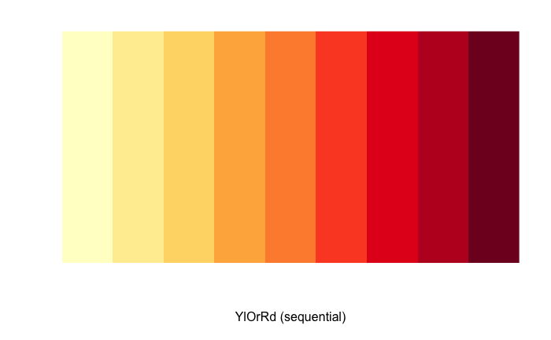

The `colorNumeric` function interpolates a discrete palette to make it continuous. We also have to input the range of values which the palette can accept. This is arbitrary, but the range has to include all the values in `df$logP`.

```r
range(df$logP)
```

```
[1]  5.086117 14.605423
```

We will use the range 0-20.

```r
pal <- colorNumeric(ylOrRd, 0:20)
```

The hex colour codes can be generated as follows

```r
pal(c(df$logP))
```

```
 [1] "#F64527" "#FB4D2A" "#EF3823" "#FED875" "#F03A23" "#FEAB49" "#E7251E" "#F33E25" "#ED3422" "#FD8A3B" "#F94A29" "#FC572C"
```